# Optimal Treatment Analysis

## Outcome Variable

**Outcome Variable:** haz

## Predictor Variables

**Intervention Variable:** nrooms

**Adjustment Set:**

- arm
- sex
- W_mage
- meducyrs
- feducyrs
- hhwealth_quart
- hfoodsec
- W_mhtcm
- W_mwtkg
- W_mbmi
- W_nchldlt5
- W_parity
- impfloor
- impsan
- safeh20
- delta_W_mage
- delta_meducyrs
- delta_feducyrs
- delta_hhwealth_quart
- delta_hfoodsec
- delta_W_mhtcm
- delta_W_mwtkg
- delta_W_mbmi
- delta_W_nchldlt5
- delta_W_parity
- delta_impfloor
- delta_impsan
- delta_safeh20

## Stratifying Variables

The analysis was stratified on these variable(s):

- agecat
- studyid
- country

## Data Summary

| agecat | studyid | country | nrooms | n_cell | n |
| --- | --- | --- | --- | --- | --- |
| Birth | CMC-V-BCS-2002 | INDIA | 4+ | 5 | 92 |
| Birth | CMC-V-BCS-2002 | INDIA | 1 | 38 | 92 |
| Birth | CMC-V-BCS-2002 | INDIA | 2 | 29 | 92 |
| Birth | CMC-V-BCS-2002 | INDIA | 3 | 20 | 92 |
| Birth | COHORTS | INDIA | 4+ | 92 | 4769 |
| Birth | COHORTS | INDIA | 1 | 3125 | 4769 |
| Birth | COHORTS | INDIA | 2 | 1385 | 4769 |
| Birth | COHORTS | INDIA | 3 | 167 | 4769 |
| Birth | CONTENT | PERU | 4+ | 1 | 2 |
| Birth | CONTENT | PERU | 1 | 0 | 2 |
| Birth | CONTENT | PERU | 2 | 1 | 2 |
| Birth | CONTENT | PERU | 3 | 0 | 2 |
| Birth | GMS-Nepal | NEPAL | 4+ | 321 | 696 |
| Birth | GMS-Nepal | NEPAL | 1 | 49 | 696 |
| Birth | GMS-Nepal | NEPAL | 2 | 145 | 696 |
| Birth | GMS-Nepal | NEPAL | 3 | 181 | 696 |
| Birth | IRC | INDIA | 4+ | 17 | 386 |
| Birth | IRC | INDIA | 1 | 175 | 386 |
| Birth | IRC | INDIA | 2 | 161 | 386 |
| Birth | IRC | INDIA | 3 | 33 | 386 |
| Birth | JiVitA-3 | BANGLADESH | 4+ | 755 | 22429 |
| Birth | JiVitA-3 | BANGLADESH | 1 | 13942 | 22429 |
| Birth | JiVitA-3 | BANGLADESH | 2 | 5846 | 22429 |
| Birth | JiVitA-3 | BANGLADESH | 3 | 1886 | 22429 |
| Birth | JiVitA-4 | BANGLADESH | 4+ | 128 | 2820 |
| Birth | JiVitA-4 | BANGLADESH | 1 | 1705 | 2820 |
| Birth | JiVitA-4 | BANGLADESH | 2 | 709 | 2820 |
| Birth | JiVitA-4 | BANGLADESH | 3 | 278 | 2820 |
| Birth | MAL-ED | BANGLADESH | 4+ | 12 | 213 |
| Birth | MAL-ED | BANGLADESH | 1 | 130 | 213 |

[output cut: 162 more lines]

The following strata were considered:

- agecat: 24 months, studyid: CMC-V-BCS-2002, country: INDIA
- agecat: 24 months, studyid: COHORTS, country: INDIA
- agecat: 24 months, studyid: CONTENT, country: PERU
- agecat: 24 months, studyid: GMS-Nepal, country: NEPAL
- agecat: 24 months, studyid: IRC, country: INDIA
- agecat: 24 months, studyid: JiVitA-3, country: BANGLADESH
- agecat: 24 months, studyid: JiVitA-4, country: BANGLADESH
- agecat: 24 months, studyid: MAL-ED, country: BANGLADESH
- agecat: 24 months, studyid: MAL-ED, country: BRAZIL
- agecat: 24 months, studyid: MAL-ED, country: INDIA
- agecat: 24 months, studyid: MAL-ED, country: NEPAL
- agecat: 24 months, studyid: MAL-ED, country: PERU
- agecat: 24 months, studyid: MAL-ED, country: SOUTH AFRICA
- agecat: 24 months, studyid: MAL-ED, country: TANZANIA, UNITED REPUBLIC OF
- agecat: 24 months, studyid: NIH-Crypto, country: BANGLADESH
- agecat: 24 months, studyid: PROVIDE, country: BANGLADESH
- agecat: 6 months, studyid: CMC-V-BCS-2002, country: INDIA
- agecat: 6 months, studyid: COHORTS, country: INDIA
- agecat: 6 months, studyid: CONTENT, country: PERU
- agecat: 6 months, studyid: GMS-Nepal, country: NEPAL
- agecat: 6 months, studyid: IRC, country: INDIA
- agecat: 6 months, studyid: JiVitA-3, country: BANGLADESH
- agecat: 6 months, studyid: JiVitA-4, country: BANGLADESH
- agecat: 6 months, studyid: MAL-ED, country: BANGLADESH
- agecat: 6 months, studyid: MAL-ED, country: BRAZIL
- agecat: 6 months, studyid: MAL-ED, country: INDIA
- agecat: 6 months, studyid: MAL-ED, country: NEPAL
- agecat: 6 months, studyid: MAL-ED, country: PERU
- agecat: 6 months, studyid: MAL-ED, country: SOUTH AFRICA
- agecat: 6 months, studyid: MAL-ED, country: TANZANIA, UNITED REPUBLIC OF
- agecat: 6 months, studyid: NIH-Crypto, country: BANGLADESH
- agecat: 6 months, studyid: PROVIDE, country: BANGLADESH
- agecat: Birth, studyid: CMC-V-BCS-2002, country: INDIA
- agecat: Birth, studyid: COHORTS, country: INDIA
- agecat: Birth, studyid: CONTENT, country: PERU
- agecat: Birth, studyid: GMS-Nepal, country: NEPAL
- agecat: Birth, studyid: IRC, country: INDIA
- agecat: Birth, studyid: JiVitA-3, country: BANGLADESH
- agecat: Birth, studyid: JiVitA-4, country: BANGLADESH
- agecat: Birth, studyid: MAL-ED, country: BANGLADESH
- agecat: Birth, studyid: MAL-ED, country: BRAZIL
- agecat: Birth, studyid: MAL-ED, country: INDIA
- agecat: Birth, studyid: MAL-ED, country: NEPAL
- agecat: Birth, studyid: MAL-ED, country: PERU
- agecat: Birth, studyid: MAL-ED, country: SOUTH AFRICA
- agecat: Birth, studyid: MAL-ED, country: TANZANIA, UNITED REPUBLIC OF
- agecat: Birth, studyid: NIH-Crypto, country: BANGLADESH
- agecat: Birth, studyid: PROVIDE, country: BANGLADESH

## Methods Detail

We’re interested in the causal parameters $E[Y_a]$ for all values of $a \in \mathcal{A}$. These parameters represent the mean outcome if, possibly contrary to fact, we intervened to set all units to have $A=a$. Under the randomization and positivity assumptions, these are identified by the statistical parameters $\psi_a=E_W[E_{Y|A,W}(Y|A=a,W)]$. In addition, we’re interested in the mean of $Y$, $E[Y]$ under no intervention (the observed mean). We will estimate these parameters by using SuperLearner to fit the relevant likelihood factors – $E_{Y|A,W}(Y|A=a,W)$ and $p(A=a|W)$, and then updating our likelihood fit using a joint TMLE.

For unadjusted analyses ($W=\{\}$), initial likelihoods were estimated using Lrnr_glm to estimate the simple $E(Y|A)$ and Lrnr_mean to estimate $p(A)$. For adjusted analyses, a small library containing Lrnr_glmnet, Lrnr_xgboost, and Lrnr_mean was used.

Having estimated these parameters, we will then use the delta method to estimate relative risks and attributable risks relative to a prespecified baseline level of $A$.

[output not shown]

# Results Detail

## Results Plots

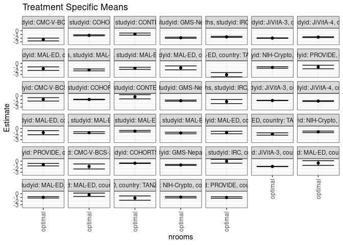

## Results Table

### Parameter: TSM

| agecat | studyid | country | intervention_level | baseline_level | estimate | ci_lower | ci_upper |
| --- | --- | --- | --- | --- | --- | --- | --- |
| Birth | CMC-V-BCS-2002 | INDIA | optimal | observed | -1.4517997 | -2.1320522 | -0.7715472 |
| Birth | COHORTS | INDIA | optimal | observed | -0.5632005 | -0.6363341 | -0.4900668 |
| Birth | GMS-Nepal | NEPAL | optimal | observed | -1.0325032 | -1.1683804 | -0.8966260 |
| Birth | IRC | INDIA | optimal | observed | -0.0333021 | -0.5480463 | 0.4814420 |
| Birth | JiVitA-3 | BANGLADESH | optimal | observed | -1.4503797 | -1.5004117 | -1.4003477 |
| Birth | MAL-ED | BANGLADESH | optimal | observed | -0.5122107 | -1.1563246 | 0.1319032 |
| Birth | MAL-ED | PERU | optimal | observed | -0.9849564 | -1.1734308 | -0.7964821 |
| Birth | MAL-ED | SOUTH AFRICA | optimal | observed | -0.2737542 | -0.7174486 | 0.1699403 |
| Birth | MAL-ED | TANZANIA, UNITED REPUBLIC OF | optimal | observed | -1.1848226 | -1.7735513 | -0.5960938 |
| Birth | NIH-Crypto | BANGLADESH | optimal | observed | -0.9386696 | -1.1329654 | -0.7443739 |
| Birth | PROVIDE | BANGLADESH | optimal | observed | -1.0200617 | -1.2275943 | -0.8125290 |
| 6 months | CMC-V-BCS-2002 | INDIA | optimal | observed | -0.9291247 | -1.3799414 | -0.4783080 |
| 6 months | COHORTS | INDIA | optimal | observed | -0.9611697 | -1.0379830 | -0.8843564 |
| 6 months | CONTENT | PERU | optimal | observed | -0.2166489 | -0.7832274 | 0.3499296 |
| 6 months | GMS-Nepal | NEPAL | optimal | observed | -1.2856061 | -1.4416154 | -1.1295967 |
| 6 months | IRC | INDIA | optimal | observed | -1.5137391 | -2.0758562 | -0.9516220 |
| 6 months | JiVitA-3 | BANGLADESH | optimal | observed | -1.2330251 | -1.2843616 | -1.1816885 |
| 6 months | JiVitA-4 | BANGLADESH | optimal | observed | -1.3895692 | -1.4818874 | -1.2972509 |
| 6 months | MAL-ED | BANGLADESH | optimal | observed | -1.1133573 | -1.6689898 | -0.5577248 |
| 6 months | MAL-ED | INDIA | optimal | observed | -1.1190135 | -1.3481059 | -0.8899212 |
| 6 months | MAL-ED | NEPAL | optimal | observed | -0.7172273 | -0.9221943 | -0.5122603 |
| 6 months | MAL-ED | PERU | optimal | observed | -1.2143611 | -1.4278851 | -1.0008372 |
| 6 months | MAL-ED | SOUTH AFRICA | optimal | observed | -1.0832394 | -1.4215750 | -0.7449038 |
| 6 months | MAL-ED | TANZANIA, UNITED REPUBLIC OF | optimal | observed | -1.4782134 | -1.7811925 | -1.1752344 |
| 6 months | NIH-Crypto | BANGLADESH | optimal | observed | -0.8953397 | -1.1057501 | -0.6849294 |
| 6 months | PROVIDE | BANGLADESH | optimal | observed | -0.9587917 | -1.3009017 | -0.6166817 |
| 24 months | CMC-V-BCS-2002 | INDIA | optimal | observed | -2.3762440 | -2.7660233 | -1.9864647 |
| 24 months | COHORTS | INDIA | optimal | observed | -1.2492265 | -1.3820100 | -1.1164430 |
| 24 months | CONTENT | PERU | optimal | observed | -0.9037878 | -1.1934458 | -0.6141297 |
| 24 months | GMS-Nepal | NEPAL | optimal | observed | -1.8958549 | -2.0557274 | -1.7359824 |
| 24 months | IRC | INDIA | optimal | observed | -1.6585010 | -1.8025925 | -1.5144096 |
| 24 months | JiVitA-3 | BANGLADESH | optimal | observed | -1.9858106 | -2.0535125 | -1.9181087 |
| 24 months | JiVitA-4 | BANGLADESH | optimal | observed | -1.7277567 | -1.8281587 | -1.6273546 |
| 24 months | MAL-ED | BANGLADESH | optimal | observed | -1.4410596 | -1.9200461 | -0.9620731 |
| 24 months | MAL-ED | INDIA | optimal | observed | -1.7817509 | -2.0279287 | -1.5355730 |
| 24 months | MAL-ED | NEPAL | optimal | observed | -1.3369605 | -1.6250704 | -1.0488506 |
| 24 months | MAL-ED | SOUTH AFRICA | optimal | observed | -1.2258834 | -1.7505178 | -0.7012491 |
| 24 months | MAL-ED | TANZANIA, UNITED REPUBLIC OF | optimal | observed | -3.0845735 | -3.6595509 | -2.5095961 |
| 24 months | NIH-Crypto | BANGLADESH | optimal | observed | -1.1171694 | -1.3176005 | -0.9167382 |
| 24 months | PROVIDE | BANGLADESH | optimal | observed | -0.9778249 | -1.4625938 | -0.4930559 |

### Parameter: E(Y)

| agecat | studyid | country | intervention_level | baseline_level | estimate | ci_lower | ci_upper |
| --- | --- | --- | --- | --- | --- | --- | --- |
| Birth | CMC-V-BCS-2002 | INDIA | observed | observed | -0.9611957 | -1.1776967 | -0.7446946 |
| Birth | COHORTS | INDIA | observed | observed | -0.6777626 | -0.7107167 | -0.6448086 |
| Birth | GMS-Nepal | NEPAL | observed | observed | -1.0851580 | -1.1651811 | -1.0051350 |
| Birth | IRC | INDIA | observed | observed | -0.3079016 | -0.4694769 | -0.1463262 |
| Birth | JiVitA-3 | BANGLADESH | observed | observed | -1.5898426 | -1.6091216 | -1.5705636 |
| Birth | MAL-ED | BANGLADESH | observed | observed | -1.0530516 | -1.1896058 | -0.9164975 |
| Birth | MAL-ED | PERU | observed | observed | -0.9141395 | -1.0364098 | -0.7918693 |
| Birth | MAL-ED | SOUTH AFRICA | observed | observed | -0.5523958 | -0.7550074 | -0.3497843 |
| Birth | MAL-ED | TANZANIA, UNITED REPUBLIC OF | observed | observed | -1.1225000 | -1.3335666 | -0.9114334 |
| Birth | NIH-Crypto | BANGLADESH | observed | observed | -0.9094945 | -0.9809370 | -0.8380521 |
| Birth | PROVIDE | BANGLADESH | observed | observed | -0.8851020 | -0.9601332 | -0.8100709 |
| 6 months | CMC-V-BCS-2002 | INDIA | observed | observed | -1.4234508 | -1.5645974 | -1.2823042 |
| 6 months | COHORTS | INDIA | observed | observed | -1.0413281 | -1.0740395 | -1.0086167 |
| 6 months | CONTENT | PERU | observed | observed | -0.2785256 | -0.4098735 | -0.1471776 |
| 6 months | GMS-Nepal | NEPAL | observed | observed | -1.3508392 | -1.4290633 | -1.2726152 |
| 6 months | IRC | INDIA | observed | observed | -1.2470123 | -1.3779341 | -1.1160906 |
| 6 months | JiVitA-3 | BANGLADESH | observed | observed | -1.3132988 | -1.3364412 | -1.2901565 |
| 6 months | JiVitA-4 | BANGLADESH | observed | observed | -1.3440477 | -1.3813060 | -1.3067894 |
| 6 months | MAL-ED | BANGLADESH | observed | observed | -1.2026806 | -1.3203025 | -1.0850586 |
| 6 months | MAL-ED | INDIA | observed | observed | -1.2070638 | -1.3255909 | -1.0885368 |
| 6 months | MAL-ED | NEPAL | observed | observed | -0.5615819 | -0.6741832 | -0.4489807 |
| 6 months | MAL-ED | PERU | observed | observed | -1.3248549 | -1.4336721 | -1.2160378 |
| 6 months | MAL-ED | SOUTH AFRICA | observed | observed | -1.0547925 | -1.1843544 | -0.9252306 |
| 6 months | MAL-ED | TANZANIA, UNITED REPUBLIC OF | observed | observed | -1.3687449 | -1.4907629 | -1.2467270 |
| 6 months | NIH-Crypto | BANGLADESH | observed | observed | -1.1986783 | -1.2700937 | -1.1272630 |
| 6 months | PROVIDE | BANGLADESH | observed | observed | -1.0916915 | -1.1661176 | -1.0172654 |
| 24 months | CMC-V-BCS-2002 | INDIA | observed | observed | -2.5588679 | -2.6583730 | -2.4593629 |
| 24 months | COHORTS | INDIA | observed | observed | -2.2131714 | -2.2523749 | -2.1739679 |
| 24 months | CONTENT | PERU | observed | observed | -0.6868598 | -0.8388476 | -0.5348719 |
| 24 months | GMS-Nepal | NEPAL | observed | observed | -1.8874180 | -1.9728588 | -1.8019773 |
| 24 months | IRC | INDIA | observed | observed | -1.8014906 | -1.8952579 | -1.7077232 |
| 24 months | JiVitA-3 | BANGLADESH | observed | observed | -2.0137471 | -2.0414306 | -1.9860636 |
| 24 months | JiVitA-4 | BANGLADESH | observed | observed | -1.7803708 | -1.8158650 | -1.7448765 |
| 24 months | MAL-ED | BANGLADESH | observed | observed | -1.9783962 | -2.1050210 | -1.8517715 |
| 24 months | MAL-ED | INDIA | observed | observed | -1.8861894 | -2.0110006 | -1.7613783 |
| 24 months | MAL-ED | NEPAL | observed | observed | -1.3075877 | -1.4270718 | -1.1881037 |
| 24 months | MAL-ED | SOUTH AFRICA | observed | observed | -1.6450595 | -1.7797240 | -1.5103950 |
| 24 months | MAL-ED | TANZANIA, UNITED REPUBLIC OF | observed | observed | -2.6455607 | -2.7807256 | -2.5103959 |
| 24 months | NIH-Crypto | BANGLADESH | observed | observed | -1.4412646 | -1.5249156 | -1.3576135 |
| 24 months | PROVIDE | BANGLADESH | observed | observed | -1.6024221 | -1.6857420 | -1.5191023 |

### Parameter: PAR

| agecat | studyid | country | intervention_level | baseline_level | estimate | ci_lower | ci_upper |
| --- | --- | --- | --- | --- | --- | --- | --- |
| Birth | CMC-V-BCS-2002 | INDIA | optimal | observed | 0.4906040 | -0.1423165 | 1.1235246 |
| Birth | COHORTS | INDIA | optimal | observed | -0.1145622 | -0.1797233 | -0.0494010 |
| Birth | GMS-Nepal | NEPAL | optimal | observed | -0.0526548 | -0.1724166 | 0.0671069 |
| Birth | IRC | INDIA | optimal | observed | -0.2745994 | -0.7760089 | 0.2268100 |
| Birth | JiVitA-3 | BANGLADESH | optimal | observed | -0.1394629 | -0.1893629 | -0.0895629 |
| Birth | MAL-ED | BANGLADESH | optimal | observed | -0.5408410 | -1.1640534 | 0.0823715 |
| Birth | MAL-ED | PERU | optimal | observed | 0.0708169 | -0.0816798 | 0.2233136 |
| Birth | MAL-ED | SOUTH AFRICA | optimal | observed | -0.2786417 | -0.7540509 | 0.1967676 |
| Birth | MAL-ED | TANZANIA, UNITED REPUBLIC OF | optimal | observed | 0.0623226 | -0.4956213 | 0.6202665 |
| Birth | NIH-Crypto | BANGLADESH | optimal | observed | 0.0291751 | -0.1546816 | 0.2130318 |
| Birth | PROVIDE | BANGLADESH | optimal | observed | 0.1349596 | -0.0685490 | 0.3384682 |
| 6 months | CMC-V-BCS-2002 | INDIA | optimal | observed | -0.4943261 | -0.9359160 | -0.0527362 |
| 6 months | COHORTS | INDIA | optimal | observed | -0.0801584 | -0.1559755 | -0.0043413 |
| 6 months | CONTENT | PERU | optimal | observed | -0.0618767 | -0.6110355 | 0.4872821 |
| 6 months | GMS-Nepal | NEPAL | optimal | observed | -0.0652332 | -0.2050509 | 0.0745846 |
| 6 months | IRC | INDIA | optimal | observed | 0.2667268 | -0.2718651 | 0.8053186 |
| 6 months | JiVitA-3 | BANGLADESH | optimal | observed | -0.0802737 | -0.1281289 | -0.0324186 |
| 6 months | JiVitA-4 | BANGLADESH | optimal | observed | 0.0455215 | -0.0419128 | 0.1329558 |
| 6 months | MAL-ED | BANGLADESH | optimal | observed | -0.0893232 | -0.6322661 | 0.4536197 |
| 6 months | MAL-ED | INDIA | optimal | observed | -0.0880503 | -0.3122534 | 0.1361528 |
| 6 months | MAL-ED | NEPAL | optimal | observed | 0.1556454 | -0.0270977 | 0.3383884 |
| 6 months | MAL-ED | PERU | optimal | observed | -0.1104938 | -0.3115870 | 0.0905994 |
| 6 months | MAL-ED | SOUTH AFRICA | optimal | observed | 0.0284469 | -0.3051841 | 0.3620779 |
| 6 months | MAL-ED | TANZANIA, UNITED REPUBLIC OF | optimal | observed | 0.1094685 | -0.1677272 | 0.3866641 |
| 6 months | NIH-Crypto | BANGLADESH | optimal | observed | -0.3033386 | -0.5015391 | -0.1051380 |
| 6 months | PROVIDE | BANGLADESH | optimal | observed | -0.1328998 | -0.4691194 | 0.2033197 |
| 24 months | CMC-V-BCS-2002 | INDIA | optimal | observed | -0.1826239 | -0.5723750 | 0.2071271 |
| 24 months | COHORTS | INDIA | optimal | observed | -0.9639449 | -1.0985509 | -0.8293389 |
| 24 months | CONTENT | PERU | optimal | observed | 0.2169280 | -0.0320447 | 0.4659007 |
| 24 months | GMS-Nepal | NEPAL | optimal | observed | 0.0084369 | -0.1225655 | 0.1394393 |
| 24 months | IRC | INDIA | optimal | observed | -0.1429896 | -0.2545536 | -0.0314255 |
| 24 months | JiVitA-3 | BANGLADESH | optimal | observed | -0.0279365 | -0.0911652 | 0.0352922 |
| 24 months | JiVitA-4 | BANGLADESH | optimal | observed | -0.0526141 | -0.1499305 | 0.0447023 |
| 24 months | MAL-ED | BANGLADESH | optimal | observed | -0.5373366 | -1.0102176 | -0.0644556 |
| 24 months | MAL-ED | INDIA | optimal | observed | -0.1044386 | -0.2986227 | 0.0897456 |
| 24 months | MAL-ED | NEPAL | optimal | observed | 0.0293728 | -0.2402426 | 0.2989882 |
| 24 months | MAL-ED | SOUTH AFRICA | optimal | observed | -0.4191761 | -0.9256183 | 0.0872661 |
| 24 months | MAL-ED | TANZANIA, UNITED REPUBLIC OF | optimal | observed | 0.4390127 | -0.1141072 | 0.9921326 |
| 24 months | NIH-Crypto | BANGLADESH | optimal | observed | -0.3240952 | -0.5165098 | -0.1316807 |
| 24 months | PROVIDE | BANGLADESH | optimal | observed | -0.6245973 | -1.0990399 | -0.1501546 |